# Personalización de un gráfico en ggplot

### Fondo del gráfico y de la leyenda

El fondo del gráfico y de la leyenda se puede cambiar a cualquier color de los enumerados [aquí](http://www.stat.columbia.edu/~tzheng/files/Rcolor.pdf) utilizando el siguiente código:

- `panel.background = element_rect()` modificará el panel detrás del gráfico.
- `legend.key = element_rect()` modificará las cajas junto a cada nombre de categoría.
- `legend.background = element_rect()` modificará la caja alrededor de los nombres y cajas de la leyenda.

Para cada uno de estos elementos, los formatos que puedes modificar son:

- `fill = "color"` para colorear el panel detrás del gráfico.
- `colour = "color"` modificará el contorno de los ejes del gráfico.
- `size = 6` modificará el grosor de este contorno.

Para demostrar cómo funciona, aquí hay un tema feo con colores obvios elegidos para mostrar las diferencias:

```r
mytheme <-
  theme(
    panel.background = element_rect(
      fill = "black",
      colour = "yellow",
      size = 4
    ),
    legend.key = element_rect(fill = "darkgrey", colour = "yellow"),
    legend.background = (element_rect(colour = "yellow", fill = "blue"))
  )
```

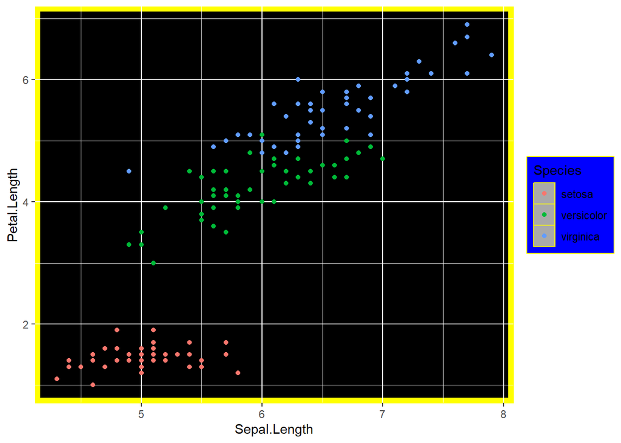

```r
print(IrisPlot + mytheme)
```

### Modificar el tamaño, color o presencia de las líneas de cuadrícula

Las líneas de cuadrícula se dividen en dos conjuntos: las líneas de cuadrícula mayores y menores. Esto te permite acentuar o eliminar la mitad de las líneas de cuadrícula. * `panel.grid.major = element_line()` - modifica el formato de las líneas de cuadrícula mayores. * `panel.grid.minor = element_line()` - modifica el formato de las líneas de cuadrícula menores.

donde `()` se usa para especificar el color y el grosor de las líneas.

Los formatos incluyen: * Color. Por ejemplo, `colour = "steelblue2"` - recuerda incluir “” antes y después del nombre del color. * Tamaño. Se especifica ingresando un número, por ejemplo, `size = 3`.

Al combinar todo esto en un tema, se vería así:

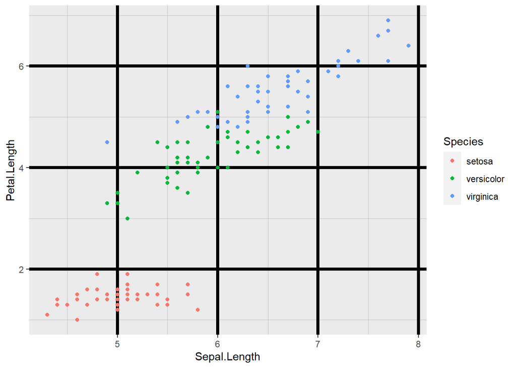

```r
mytheme <-
  theme(
    panel.grid.major = element_line(colour = "black", size = (1.5)),
    panel.grid.minor = element_line(
      size = (0.2), colour =
        "grey"
    )
  )

print(IrisPlot + mytheme)
```

Para remover las líneas de cuadrícula, puedes usar `element_blank()`

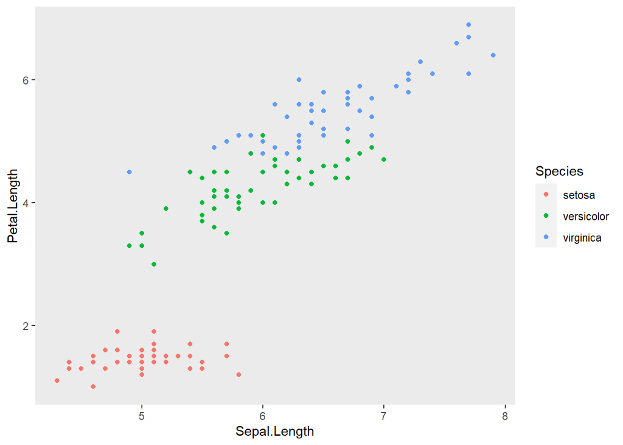

```r
mytheme <- theme(panel.grid.minor = element_blank(), panel.grid.major = element_blank())

print(IrisPlot + mytheme)
```

### Modificación de las líneas de los ejes x e y

El tamaño y el color de las líneas de los ejes se pueden personalizar de la misma manera que las líneas de la cuadrícula (arriba), utilizando `axis.line = element_line()`. Por ejemplo:

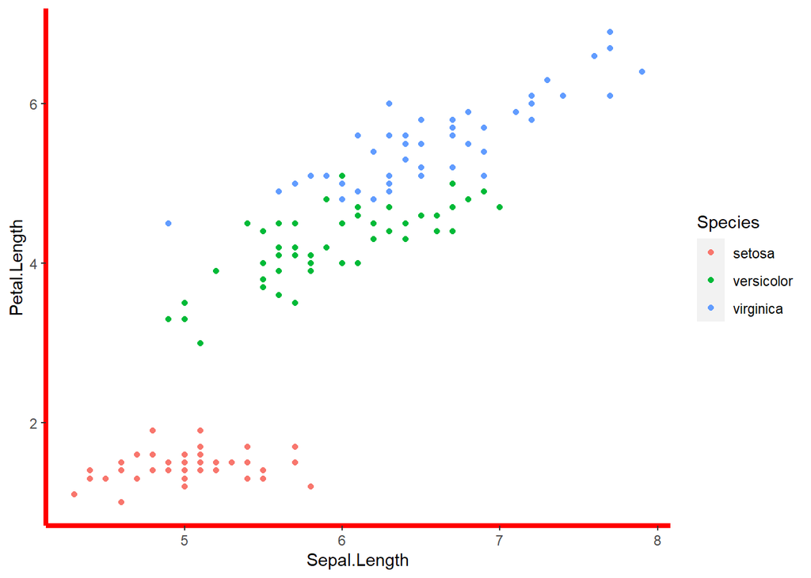

```r
mytheme <-
  theme(
    axis.line = element_line(size = 1.5, colour = "red"),
    panel.background = element_rect(fill = "white")
  )

print(IrisPlot + mytheme)
```

### Modificación de las marcas de los ejes

El tamaño y el color de las marcas de los ejes se pueden alterar utilizando `axis.ticks = element_line( )`. Por ejemplo:

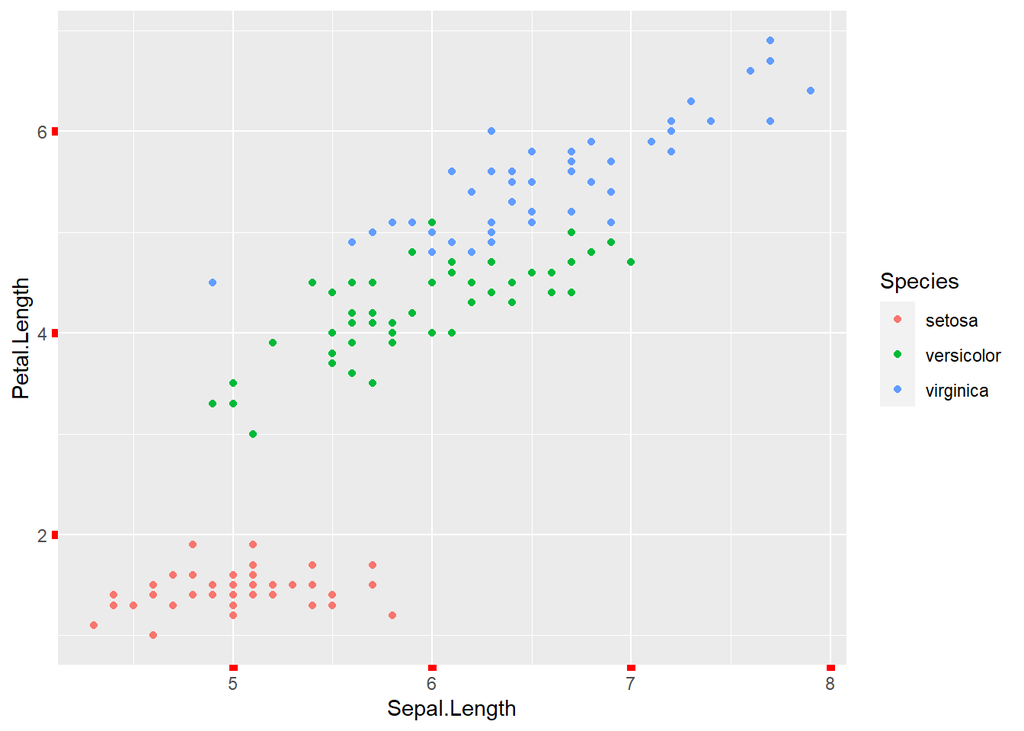

```r
mytheme <- theme(axis.ticks = element_line(colour = "red", size = (2)))

print(IrisPlot + mytheme)
```

### Eliminación de cualquier elemento de un tema

Se utiliza `= element_blank()` si deseas eliminar completamente un elemento del formato. Por ejemplo, para eliminar las marcas, las líneas de la cuadrícula y el fondo, utilizarías:

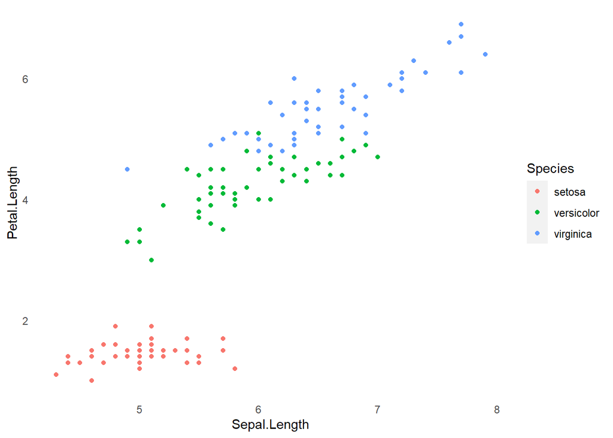

```r
mytheme <-
  theme(
    axis.ticks = element_blank(),
    panel.grid.minor = element_blank(),
    panel.grid.major = element_blank(),
    panel.background = element_blank()
  )

print(IrisPlot + mytheme)
```

### Ejemplo de un ggplot completamente personalizado

Aquí tienes un ejemplo de un ggplot con muchos elementos personalizados. Obviamente, es mucho código, pero recuerda que puedes guardar y reutilizar tu tema favorito tantas veces como quieras. Consulta la página sobre Agregar títulos y nombres de ejes para obtener ayuda con esas partes del código `print()`.

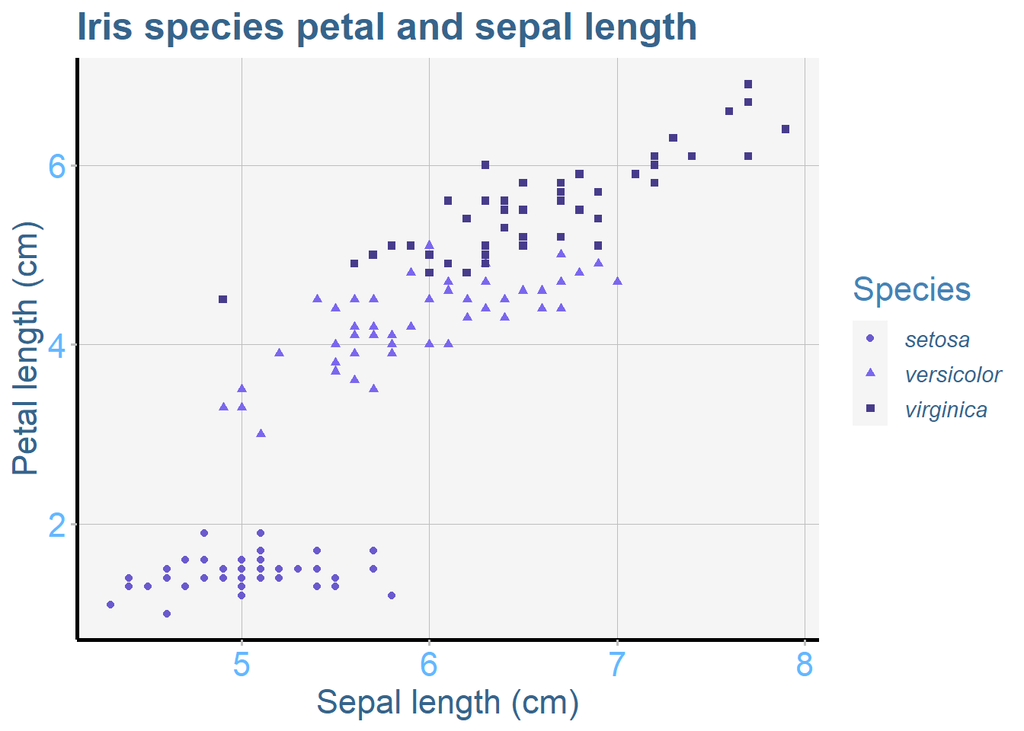

```r
IrisPlot <-
  ggplot(
    iris,
    aes(
      Sepal.Length,
      Petal.Length,
      colour = Species,
      shape = Species
    )
  ) +
  geom_point()

mytheme3 <-
  theme(
    legend.text = element_text(
      face = "italic",
      colour = "steelblue4",
      family = "Helvetica",
      size = rel(1)
    ),
    axis.title = element_text(
      colour = "steelblue4",
      family = "Helvetica",
      size = rel(1.5)
    ),
    axis.text = element_text(
      family = "Helvetica",
      colour = "steelblue1",
      size = rel(1.5)
    ),
    axis.line = element_line(size = 1, colour = "black"),
    axis.ticks = element_line(colour = "grey", size = rel(1.4)),
    panel.grid.major = element_line(colour = "grey", size = rel(0.5)),
    panel.grid.minor = element_blank(),
    panel.background = element_rect(fill = "whitesmoke"),
    legend.key = element_rect(fill = "whitesmoke"),
    legend.title = element_text(
      colour = "steelblue",
      size = rel(1.5),
      family = "Helvetica"
    ),
    plot.title = element_text(
      colour = "steelblue4",
      face = "bold",
      size = rel(1.7),
      family = "Helvetica"
    )
  )

print(
  IrisPlot + mytheme3 + ggtitle("Iris species petal and sepal length")
    + labs(y = "Petal length (cm)", x = "Sepal length (cm)", colour = "Species")
    + scale_colour_manual(values = c("slateblue", "slateblue2", "slateblue4"))
)
```

### Más ayuda

Para personalizar aún más la estética del gráfico, incluyendo el color y el formato, consulta nuestras otras páginas de ayuda de ggplot: * Agregar títulos y nombres de ejes * Colores y símbolos.

Puedes encontrar ayuda sobre todas las funciones de ggplot en [el sitio de ayuda principal de ggplot](https://ggplot2.tidyverse.org).

Puedes descargar una hoja de referencia útil sobre las funciones más utilizadas [aquí](https://raw.githubusercontent.com/rstudio/cheatsheets/main/data-visualization.pdf).

Chang, W (2012) *R Graphics cookbook.* O’Reilly Media. - una guía sobre ggplot con bastante ayuda en línea [aquí](http://www.cookbook-r.com/Graphs/)

**Autor**: Fiona Robinson

**Año**: 2016

**Última actualización**: Jun. 2023